# Markdown notes

2024-03-27

The three little backticks tells R that we’re going to be putting in code Anything outside of the three little backticks is treated as text. This lets you incorporate your methods, reasoning, etc. in this report

Here’s a summary of mtcars

```r
summary(mtcars)
```

```
##       mpg             cyl             disp             hp
##  Min.   :10.40   Min.   :4.000   Min.   : 71.1   Min.   : 52.0
##  1st Qu.:15.43   1st Qu.:4.000   1st Qu.:120.8   1st Qu.: 96.5
##  Median :19.20   Median :6.000   Median :196.3   Median :123.0
##  Mean   :20.09   Mean   :6.188   Mean   :230.7   Mean   :146.7
##  3rd Qu.:22.80   3rd Qu.:8.000   3rd Qu.:326.0   3rd Qu.:180.0
##  Max.   :33.90   Max.   :8.000   Max.   :472.0   Max.   :335.0
##       drat             wt             qsec             vs
##  Min.   :2.760   Min.   :1.513   Min.   :14.50   Min.   :0.0000
##  1st Qu.:3.080   1st Qu.:2.581   1st Qu.:16.89   1st Qu.:0.0000
##  Median :3.695   Median :3.325   Median :17.71   Median :0.0000
##  Mean   :3.597   Mean   :3.217   Mean   :17.85   Mean   :0.4375
##  3rd Qu.:3.920   3rd Qu.:3.610   3rd Qu.:18.90   3rd Qu.:1.0000
##  Max.   :4.930   Max.   :5.424   Max.   :22.90   Max.   :1.0000
##        am              gear            carb
##  Min.   :0.0000   Min.   :3.000   Min.   :1.000
##  1st Qu.:0.0000   1st Qu.:3.000   1st Qu.:2.000
##  Median :0.0000   Median :4.000   Median :2.000
##  Mean   :0.4062   Mean   :3.688   Mean   :2.812
##  3rd Qu.:1.0000   3rd Qu.:4.000   3rd Qu.:4.000
##  Max.   :1.0000   Max.   :5.000   Max.   :8.000
```

Here’s a plot of miles per gallon as a function of hp

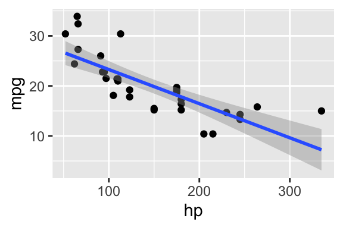

```r
ggplot(mtcars, aes(x=hp,y=mpg))+
  geom_point()+
  geom_smooth(method="lm")
```

The message = false makes it so that R won’t show the output message of this plot (e.g., it’s not going to show ## `geom_smooth()` using formula = ‘y ~ x’) Warning = false means that it won’t show any warnings that R spits out at you in the report

What about text??

# Text

## Text

### Text

#### Text

The hashtag no longer means comment, it formats the text into headings

**bold**

*italic*

On the course website, the markdown live preview generator will let you see what your html will look like in real time

You can google R markdown cheat cheat and find some very helpful documents In the code, if you put echo=FALSE, then it won’t fucking put the code in the report

Let’s do a simple model, modeling the effect of various factors on miles per gallon

We built two versions of the model. The first is linear, the second is a second-order polynomial. Both use hp as the only predictor

Let’s make a plot:

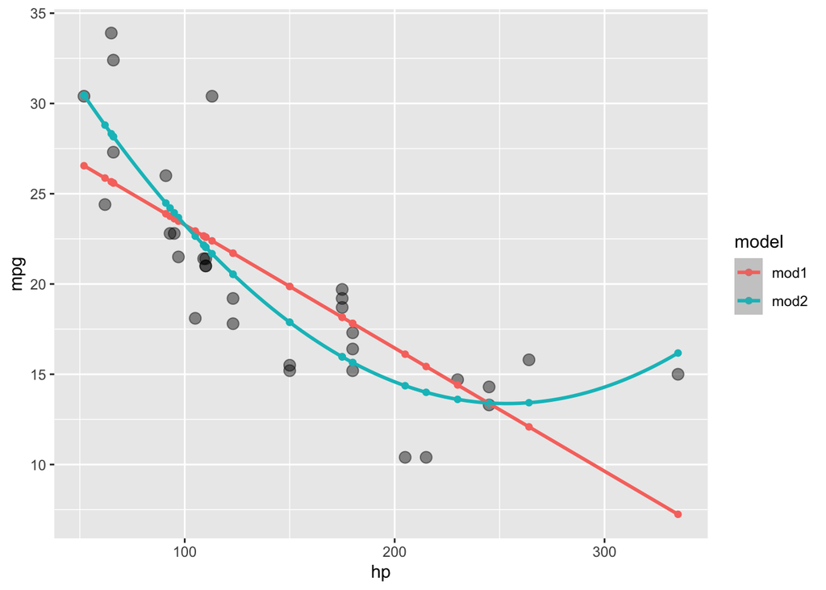

```r
mean(residuals(mod1)^2)
```

```
## [1] 13.98982
```

```r
mean(residuals(mod2)^2)
```

```
## [1] 8.582239
```